# R Modeling Workshop

Marissa Barlaz  
February 26 & 28, 2018

## What is the point?

When looking at data, we want to determine if there is a relationship between our independent and dependent variables. A traditional method of analysis in Linguistics and associated fields is regression analysis, which helps understand how a particular variable (the dependent variable) changes when other variables (independent variables, or predictors) are varied.

When running regression analyses, the dependent variable must be continuous. The independent variables can be continuous, discrete, or categorical.

When we run regression analyses on our data, we first need to make sure a few basic assumptions are met:

- The sample is representative of the population.
- The predictors are measured with no error.
- The predictors are linearly independent, i.e. it is not possible to express any predictor as a linear combination of the others.

We will go through further assumptions as we go through the workshop.

## Data

The data I will be using during this tutorial is from the University of Wisconsin's X-Ray Microbeam Speech Production Database. The database has the following variables:

- v = vowel
- f0
- f1-f4
- ulx and uly = x and y coordinates of the upper lip
- llx and lly = x and y coordinates of the lower lip
- t(1-4)x and t(1-4)y = x and y coordinates of the tongue at position (1-4)
- mnix and mniy = x and y coordinates of the mandibular incisor
- mnmx and mnmy = x and y coordinates of the mandibular molar

```r
ubdb = read.csv("ubdb.csv", header = T)
head(ubdb)
```

```
##    v       f0      f1       f2      f3      f4   ulx   uly   llx    lly
## 1 AA 117.9440 685.407 1197.050 2191.48 3336.96 13932 18276  6539 -30434
## 2 IH 112.8280 418.372  985.526 2487.43 3011.10 20501 20067  5382 -22754
## 3 AO  93.0954 590.657  972.832 2020.60 2789.85 19325 19404 13488 -16881
## 4 EH 102.2070 614.993 1477.480 2312.54 3231.13 14055 18779  8355 -31634
## 5 AO  95.1051 560.905 1071.830 1815.31 2777.59 19559 21403 13222 -17716
## 6 IH 100.8450 201.074 1246.360 2390.22 3494.73 13907 16145 10587 -16234
##      t1x   t1y    t2x   t2y    t3x   t3y    t4x   t4y  mnix   mniy   mnmx
## 1 -23064 -4335 -35728  -255 -46156  6775 -57700 13213 -1210 -12864 -42867
## 2 -19155  5498 -30598 10135 -41026 14935 -55410 17009 -1726  -6362 -44347
## 3 -27701    85 -36820 10226 -46626 17044 -60265 18089  -646 -11293 -42029
## 4 -13440 -8626 -25020  -878 -35575  6039 -48541  7436   953 -16019 -40606
## 5 -23812  3805 -32471 12748 -42574 18192 -56299 15808   191 -11150 -41519
## 6 -19836  4807 -29710 11789 -40145 17257 -55107 14865 -1886  -7813 -44639
##     mnmy
## 1  -8388
## 2  -3640
## 3  -7787
## 4 -10839
## 5  -7347
## 6  -4746
```

```r
summary(ubdb)
```

```
##        v             f0               f1               f2
##  IH     :206   Min.   :  0.00   Min.   :  89.3   Min.   : 684.9
##  IY     :197   1st Qu.: 89.19   1st Qu.: 291.2   1st Qu.:1220.0
##  AH     :136   Median : 96.81   Median : 430.1   Median :1484.1
##  AE     :124   Mean   : 94.07   Mean   : 437.4   Mean   :1497.9
##  UX     :110   3rd Qu.:103.18   3rd Qu.: 564.2   3rd Qu.:1758.3
##  AO     :109   Max.   :137.50   Max.   :1284.5   Max.   :2572.6
##  (Other):191
##        f3             f4            ulx             uly
##  Min.   :1368   Min.   :2297   Min.   :11793   Min.   :11444
##  1st Qu.:2188   1st Qu.:3093   1st Qu.:14134   1st Qu.:17027
##  Median :2352   Median :3383   Median :14976   Median :18033
##  Mean   :2375   Mean   :3397   Mean   :15366   Mean   :17877
##  3rd Qu.:2525   3rd Qu.:3652   3rd Qu.:16201   3rd Qu.:18825
##  Max.   :3837   Max.   :4689   Max.   :21092   Max.   :23841
##
##       llx             lly              t1x              t1y
##  Min.   :  461   Min.   :-35268   Min.   :-36533   Min.   :-14089.0
##  1st Qu.: 7249   1st Qu.:-24962   1st Qu.:-19836   1st Qu.: -3307.0
##  Median : 8931   Median :-22224   Median :-15257   Median :   -54.0
##  Mean   : 9000   Mean   :-22393   Mean   :-16737   Mean   :  -218.9
##  3rd Qu.:10810   3rd Qu.:-19517   3rd Qu.:-12428   3rd Qu.:  3389.0
##  Max.   :17787   Max.   :-11031   Max.   : -5494   Max.   : 14836.0
##
##       t2x              t2y             t3x              t3y
##  Min.   :-43405   Min.   :-7592   Min.   :-52913   Min.   : 1051
##  1st Qu.:-31378   1st Qu.: 4132   1st Qu.:-42054   1st Qu.:11226
##  Median :-26343   Median : 8426   Median :-37292   Median :16017
##  Mean   :-27558   Mean   : 7863   Mean   :-38021   Mean   :15338
##  3rd Qu.:-23596   3rd Qu.:11900   3rd Qu.:-34018   3rd Qu.:20273
##  Max.   :-16923   Max.   :19404   Max.   :-27306   Max.   :24056
##
##       t4x              t4y             mnix            mniy
##  Min.   :-66180   Min.   : 7436   Min.   :-4160   Min.   :-19839
##  1st Qu.:-55572   1st Qu.:15148   1st Qu.:-1674   1st Qu.: -9919
##  Median :-51926   Median :18906   Median :-1081   Median : -7640
##  Mean   :-52621   Mean   :18747   Mean   :-1033   Mean   : -8321
##  3rd Qu.:-49451   3rd Qu.:22853   3rd Qu.: -467   3rd Qu.: -6055
##  Max.   :-43324   Max.   :25995   Max.   : 3410   Max.   : -3140
##
##       mnmx             mnmy
##  Min.   :-47257   Min.   :-12229
##  1st Qu.:-44127   1st Qu.: -4419
##  Median :-43396   Median : -2558
##  Mean   :-43309   Mean   : -3030
##  3rd Qu.:-42593   3rd Qu.: -1300
##  Max.   :-38797   Max.   :  1029
##
```

## Simple linear regression

Let's say we want to determine if there is a predictable relationship between articulation and acoustics. Let's see if there is a relationship between tongue height and the first formant. The first thing we want to do is examine the data.

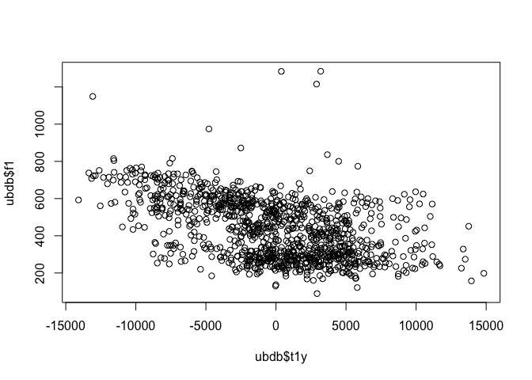

```r
plot(ubdb$t1y, ubdb$f1)
```

It looks like the relationship is linear (specifically, of the form y=mx+b+e) based on a first glance at the data. We can model the relationship between these two variables using the *lm()* function.

```r
lm1 = lm(f1~t1y, data = ubdb)
summary(lm1)
```

```
##
## Call:
## lm(formula = f1 ~ t1y, data = ubdb)
##
## Residuals:
##     Min      1Q  Median      3Q     Max
## -320.84 -112.21    1.22  102.13  900.21
##
## Coefficients:
##               Estimate Std. Error t value Pr(>|t|)
## (Intercept)  4.340e+02  4.373e+00   99.25   <2e-16 ***
## t1y         -1.557e-02  8.544e-04  -18.23   <2e-16 ***
## ---
## Signif. codes:  0 '***' 0.001 '**' 0.01 '*' 0.05 '.' 0.1 ' ' 1
##
## Residual standard error: 143.1 on 1071 degrees of freedom
## Multiple R-squared:  0.2367, Adjusted R-squared:  0.236
## F-statistic: 332.2 on 1 and 1071 DF,  p-value: < 2.2e-16
```

What does this mean? The intercept (often labeled the constant) is the expected mean value of y (the dependent variable) when all x (the independent variable(s)) equal(s) 0.

We then need to check to make sure the model is well fit, by ensuring some more criteria are met. First, we need to make sure the residuals of the model are homoscedastic, meaning variance of the residuals does not increase with fitted values. If there is absolutely no heteroscedastity, you should see a completely random, equal distribution of points throughout the range the x axis and a flat red line, for the first and third plots.

Another way to check to make sure there is no significant heteroscedastity is the Breush-Pagan test.

```r
bptest(lm1)
```

```
##
##  studentized Breusch-Pagan test
##
## data:  lm1
## BP = 0.28531, df = 1, p-value = 0.5932
```

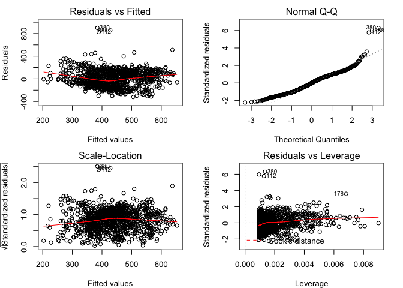

```r
par(mar = c(4, 4, 2, 2), mfrow = c(2, 2))
plot(lm1)
```

```r
lmtest::bptest(lm1)
```

```
##
##  studentized Breusch-Pagan test
##
## data:  lm1
## BP = 0.28531, df = 1, p-value = 0.5932
```

Here, we see p > 0.05, so we cannot reject the null hypothesis, and therefore there is no significant heteroscedastity.

There are more assumptions, which I will not go into for the sake of time, but are discussed here:

https://www.r-bloggers.com/basic-assumptions-to-be-taken-care-of-when-building-a-predictive-model-2/

## Moving beyond simple linear regression

What happens if we include more data in the model? For example, I only used the first tongue pellet here. What happens if we include all four tongue pellets in the analysis? Is this model better than the first one? We can compare models using *anova()* to see if they are different, and compare the R<sup>2</sup> values.

```r
lm2 = lm(f1~t1y+t2y+t3y+t4y, data = ubdb)
summary(lm2)
```

```
##
## Call:
## lm(formula = f1 ~ t1y + t2y + t3y + t4y, data = ubdb)
##
## Residuals:
##     Min      1Q  Median      3Q     Max
## -414.33  -74.78    0.83   70.44  991.84
##
## Coefficients:
##               Estimate Std. Error t value Pr(>|t|)
## (Intercept)  7.409e+02  1.800e+01  41.169  < 2e-16 ***
## t1y         -1.155e-02  1.693e-03  -6.824 1.48e-11 ***
## t2y          9.897e-06  3.697e-03   0.003    0.998
## t3y         -2.668e-04  4.052e-03  -0.066    0.948
## t4y         -1.611e-02  2.409e-03  -6.686 3.69e-11 ***
## ---
## Signif. codes:  0 '***' 0.001 '**' 0.01 '*' 0.05 '.' 0.1 ' ' 1
##
## Residual standard error: 125.8 on 1068 degrees of freedom
## Multiple R-squared:  0.4116, Adjusted R-squared:  0.4094
## F-statistic: 186.8 on 4 and 1068 DF,  p-value: < 2.2e-16
```

```r
bptest(lm2)
```

```
##
##  studentized Breusch-Pagan test
##
## data:  lm2
## BP = 7.9782, df = 4, p-value = 0.09238
```

```r
anova(lm1, lm2)
```

```
## Analysis of Variance Table
##
## Model 1: f1 ~ t1y
## Model 2: f1 ~ t1y + t2y + t3y + t4y
##   Res.Df      RSS Df Sum of Sq     F    Pr(>F)
## 1   1071 21937433
## 2   1068 16911652  3   5025781 105.8 < 2.2e-16 ***
## ---
## Signif. codes:  0 '***' 0.001 '**' 0.01 '*' 0.05 '.' 0.1 ' ' 1
```

Here, what do the results mean? For each predictor, if we hold all other predictors constant and only increase the predictor in question by 1 unit, then f1 will change by the estimate of that predictor.

So, what would happen to f1 if we changed t2y by one unit? Is this a significant change in f1?

### Interactions

Let's try interactions. Interactions allow us assess the extent to which the association between one predictor and the outcome depends on a second predictor. For example, does the effect of tongue (tip) height on F1 also depend on tongue (dorsum) height?

```r
lm3 = lm(f1~t1y*t4y, data = ubdb)
summary(lm3)
```

```
##
## Call:
## lm(formula = f1 ~ t1y * t4y, data = ubdb)
##
## Residuals:
##     Min      1Q  Median      3Q     Max
## -423.89  -71.62   -6.74   72.11  967.31
##
## Coefficients:
##               Estimate Std. Error t value Pr(>|t|)
## (Intercept)  7.230e+02  1.767e+01  40.923  < 2e-16 ***
## t1y         -3.044e-02  3.301e-03  -9.222  < 2e-16 ***
## t4y         -1.571e-02  9.092e-04 -17.282  < 2e-16 ***
## t1y:t4y      1.080e-06  1.846e-07   5.852 6.43e-09 ***
## ---
## Signif. codes:  0 '***' 0.001 '**' 0.01 '*' 0.05 '.' 0.1 ' ' 1
##
## Residual standard error: 123.8 on 1069 degrees of freedom
## Multiple R-squared:  0.4298, Adjusted R-squared:  0.4282
## F-statistic: 268.6 on 3 and 1069 DF,  p-value: < 2.2e-16
```

### Categorical Predictors

What about categorical predictors? First, we need to make sure the categorical predictor is treated as a factor, not as a numeric. You can check that using the *str()* function. If you need to change the structure to factor, use the *factor()* function. This model includes the intercept as the vowel "AA." Each estimate is the predicted change in f1 when going from AA to that vowel.

```r
ubdb$v = factor(ubdb$v)
lm4 = lm(f1~v, data = ubdb)
summary(lm4)
```

```
##
## Call:
## lm(formula = f1 ~ v, data = ubdb)
##
## Residuals:
##     Min      1Q  Median      3Q     Max
## -399.48  -68.30    2.01   78.64  900.18
##
## Coefficients:
##             Estimate Std. Error t value Pr(>|t|)
## (Intercept)   618.86      14.92  41.491  < 2e-16 ***
## vAE           -68.35      18.90  -3.617 0.000311 ***
## vAH          -143.22      18.58  -7.709 2.90e-14 ***
## vAO           -70.64      19.38  -3.645 0.000280 ***
## vEH          -141.49      19.61  -7.216 1.02e-12 ***
## vIH          -234.54      17.42 -13.463  < 2e-16 ***
## vIY          -288.87      17.53 -16.482  < 2e-16 ***
## vUW          -257.56      38.81  -6.637 5.09e-11 ***
## vUX          -326.11      19.34 -16.859  < 2e-16 ***
## ---
## Signif. codes:  0 '***' 0.001 '**' 0.01 '*' 0.05 '.' 0.1 ' ' 1
##
## Residual standard error: 129.2 on 1064 degrees of freedom
## Multiple R-squared:  0.3823, Adjusted R-squared:  0.3777
## F-statistic: 82.32 on 8 and 1064 DF,  p-value: < 2.2e-16
```

Now we can integrate previous models together.

```r
lm5 = lm(f1~t1y*t4y + v, data = ubdb)
summary(lm5)
```

```
##
## Call:
## lm(formula = f1 ~ t1y * t4y + v, data = ubdb)
##
## Residuals:
##     Min      1Q  Median      3Q     Max
## -449.24  -62.87   -0.87   61.56  929.03
##
## Coefficients:
##               Estimate Std. Error t value Pr(>|t|)
## (Intercept)  6.806e+02  2.257e+01  30.150  < 2e-16 ***
## t1y         -2.860e-02  3.209e-03  -8.912  < 2e-16 ***
## t4y         -7.953e-03  1.303e-03  -6.103 1.46e-09 ***
## vAE         -3.899e+01  1.731e+01  -2.252   0.0245 *
## vAH         -1.148e+02  1.699e+01  -6.754 2.36e-11 ***
## vAO         -2.055e+01  1.825e+01  -1.126   0.2606
## vEH         -8.432e+01  1.796e+01  -4.695 3.01e-06 ***
## vIH         -1.193e+02  1.807e+01  -6.605 6.27e-11 ***
## vIY         -1.541e+02  2.066e+01  -7.460 1.79e-13 ***
## vUW         -1.761e+02  3.517e+01  -5.007 6.48e-07 ***
## vUX         -1.953e+02  2.175e+01  -8.979  < 2e-16 ***
## t1y:t4y      1.067e-06  1.811e-07   5.892 5.13e-09 ***
## ---
## Signif. codes:  0 '***' 0.001 '**' 0.01 '*' 0.05 '.' 0.1 ' ' 1
##
## Residual standard error: 115.6 on 1061 degrees of freedom
## Multiple R-squared:  0.5065, Adjusted R-squared:  0.5014
## F-statistic: 98.99 on 11 and 1061 DF,  p-value: < 2.2e-16
```

```r
anova(lm5, lm4)
```

```
## Analysis of Variance Table
##
## Model 1: f1 ~ t1y * t4y + v
## Model 2: f1 ~ v
##   Res.Df      RSS Df Sum of Sq      F    Pr(>F)
## 1   1061 14184389
## 2   1064 17753182 -3  -3568794 88.983 < 2.2e-16 ***
## ---
## Signif. codes:  0 '***' 0.001 '**' 0.01 '*' 0.05 '.' 0.1 ' ' 1
```

### Predicting Values

One thing we can do with regression models is try to predict what the dependent variable would be, given certain values of the independent variable. To do this, we generate a data frame with the independent variables as columns, and their hypothetical values in each row. We then can use the *predict()* function to determine the predicted value, given the regression model. Note that you need a column for each predictor that exists in your model.

```r
predictdata1 = with(ubdb,expand.grid(t1y = c(4444, 11111)))
head(predictdata1)
```

```
##     t1y
## 1  4444
## 2 11111
```

```r
cbind(predictdata1, predict(lm1, type = "response",
                       se.fit = TRUE, interval="confidence",
                       newdata = predictdata1))
```

```
##     t1y  fit.fit  fit.lwr  fit.upr   se.fit   df residual.scale
## 1  4444 364.8232 353.2212 376.4253  5.91284 1071       143.1193
## 2 11111 261.0065 240.1670 281.8461 10.62060 1071       143.1193
```

```r
predictdata5 = with(ubdb,expand.grid(t1y = c(4444, -2222), t4y =c(13213, 16161),v = c("AA", "UW")))
head(predictdata5)
```

```
##     t1y   t4y  v
## 1  4444 13213 AA
## 2 -2222 13213 AA
## 3  4444 16161 AA
## 4 -2222 16161 AA
## 5  4444 13213 UW
## 6 -2222 13213 UW
```

```r
cbind(predictdata5, predict(lm5, type = "response",
                       se.fit = TRUE, interval="confidence",
                       newdata = predictdata5))
```

```
##     t1y   t4y  v  fit.fit  fit.lwr  fit.upr   se.fit   df residual.scale
## 1  4444 13213 AA 511.0152 480.3579 541.6724 15.62390 1061       115.6239
## 2 -2222 13213 AA 607.6958 581.4017 633.9899 13.40031 1061       115.6239
## 3  4444 16161 AA 501.5453 471.7848 531.3057 15.16686 1061       115.6239
## 4 -2222 16161 AA 577.2623 549.9431 604.5815 13.92271 1061       115.6239
## 5  4444 13213 UW 334.9478 270.6786 399.2170 32.75362 1061       115.6239
## 6 -2222 13213 UW 431.6284 367.8961 495.3606 32.47994 1061       115.6239
## 7  4444 16161 UW 325.4779 262.2974 388.6584 32.19876 1061       115.6239
## 8 -2222 16161 UW 401.1949 338.0526 464.3372 32.17929 1061       115.6239
```

### Binary Outcomes

Many linguistics experiments will have a binary outcome. In this case, our simple linear regression won't work, as the *lm()* function takes only a continuous variable as its dependent variable. Therefore, we need to use another function - *glm()*.

Let's see if the f1 value can predict whether a vowel is a high or low vowel. First, we need to conditionally include this information. Then, we can run the model. We need to specify that this is a binomial model. (Note that if you want to run a model with three or more levels of your predictor variable, a binary logistic regression is no longer appropriate, and the model will not work. You need to use another type of analysis, such as a multinomial logistic regression, which I will not go into detail about here.)

```r
mylevels = levels(ubdb$v)[1:4]
ubdb$vlow <- factor(ifelse(ubdb$v %in% mylevels,"LOW", "HIGH"))

glm1 = glm(vlow~f1+t1y, data = ubdb, family = "binomial")

glm2 = glm(vlow~f1+t1y+v, data = ubdb, family = "binomial")
#what's wrong with this glm?


predictdata6 = with(ubdb,expand.grid(t1y = c(4444, -2222), f1 =c(666, 333)))
cbind(predictdata6, predict(glm1, type = "response",
                       se.fit = TRUE, interval="confidence",
                       newdata = predictdata6))
```

```
##     t1y  f1       fit     se.fit residual.scale
## 1  4444 666 0.6454607 0.04245873              1
## 2 -2222 666 0.7951722 0.02294796              1
## 3  4444 333 0.1570787 0.01576620              1
## 4 -2222 333 0.2843710 0.02275635              1
```

## Polynomial Regression

Sometimes, a linear line might not be considered the best model of our data. There are multiple ways of modeling data besides a linear relationship, including higher-order polynomials. We can include the polynomial in the *lm()* function, because even though we are fitting a higher-order line to the data, the model still falls in the linear regression family because the relationship between coefficients is linear. (Examples of nonlinear regressions inclue exponential, and logarithmic regressions.)

```r
lm7 = lm(f1~t1y + I(t1y^2), data = ubdb)
summary(lm7)
```

```
##
## Call:
## lm(formula = f1 ~ t1y + I(t1y^2), data = ubdb)
##
## Residuals:
##     Min      1Q  Median      3Q     Max
## -343.20 -108.72   -4.84  105.93  910.47
##
## Coefficients:
##               Estimate Std. Error t value Pr(>|t|)
## (Intercept)  4.127e+02  5.350e+00  77.139  < 2e-16 ***
## t1y         -1.473e-02  8.471e-04 -17.390  < 2e-16 ***
## I(t1y^2)     8.205e-07  1.232e-07   6.658 4.42e-11 ***
## ---
## Signif. codes:  0 '***' 0.001 '**' 0.01 '*' 0.05 '.' 0.1 ' ' 1
##
## Residual standard error: 140.3 on 1070 degrees of freedom
## Multiple R-squared:  0.2671, Adjusted R-squared:  0.2657
## F-statistic:   195 on 2 and 1070 DF,  p-value: < 2.2e-16
```

```r
f <- function(x,c) coef(lm7)[1] + coef(lm7)[2]*x + coef(lm7)[3]*x^2

pl <- ggplot(ubdb) + geom_point(aes(x=t1y, y=f1), size=2, colour="#993399")  + geom_abline(intercept=coef(lm1)[1],slope=coef(lm1)[2],size=1, colour="#339900") +
  stat_function(fun=f, colour="red", size=1)+ylim(c(0,2000))
```

## Mixed Effects Models

The type of model that is used most often in linguistics research is the mixed effects model. Mixed effects models have two types of independent variables: fixed effects and random effects. For fixed effects, the observed values are of direct interest. For example, vowel quality, experimental condition, language background, etc., can be considered a fixed effect. In this example, *v* is a fixed effect. Random effects, on the other hand, are not of direct interest in the model. The goal is to make inferences to a general population based on the observed differences between levels. Speaker or participant is a common random effect.

How do we encode random effects? It depends on what you are trying to do. First, running a null model (with only random effects, but no fixed effects), allows a preliminary understanding of the variance between levels of the random effect. Because the current dataset does not have any random effects, I have "created" them.

```r
myspeakers = c("S1", "S2", "S3", "S4", "S5")
ubdb$speaker = factor(sample(myspeakers, dim(ubdb)[1], replace = TRUE))
lme1= lmer(f1~1+(1|speaker), data = ubdb, REML = FALSE)
summary(lme1)
```

```
## summary from lme4 is returned
## some computational error has occurred in lmerTest

## Linear mixed model fit by maximum likelihood  ['lmerMod']
## Formula: f1 ~ 1 + (1 | speaker)
##    Data: ubdb
##
##      AIC      BIC   logLik deviance df.resid
##  13991.0  14005.9  -6992.5  13985.0     1070
##
## Scaled residuals:
##     Min      1Q  Median      3Q     Max
## -2.1271 -0.8934 -0.0448  0.7746  5.1757
##
## Random effects:
##  Groups   Name        Variance Std.Dev.
##  speaker  (Intercept)     0      0.0
##  Residual             26786    163.7
## Number of obs: 1073, groups:  speaker, 5
##
## Fixed effects:
##             Estimate Std. Error t value
## (Intercept)  437.433      4.996   87.55
```

The variance in random factor tells you how much variability there is between individuals across all vowels, not the level of variance between individuals within each vowel category.

Now let's see if we can model f1 based on tongue position and speaker.

```r
lme2= lmer(f1~t1y+(1|speaker), data = ubdb, REML = FALSE)
summary(lme2)
```

```
## Warning: Some predictor variables are on very different scales: consider
## rescaling

## Warning: Some predictor variables are on very different scales: consider
## rescaling

## Warning: Some predictor variables are on very different scales: consider
## rescaling

## Linear mixed model fit by maximum likelihood t-tests use Satterthwaite
##   approximations to degrees of freedom [lmerMod]
## Formula: f1 ~ t1y + (1 | speaker)
##    Data: ubdb
##
##      AIC      BIC   logLik deviance df.resid
##  13702.9  13722.9  -6847.5  13694.9     1069
##
## Scaled residuals:
##     Min      1Q  Median      3Q     Max
## -2.2275 -0.7878  0.0051  0.7137  6.3030
##
## Random effects:
##  Groups   Name        Variance Std.Dev.
##  speaker  (Intercept)    25.41   5.041
##  Residual             20419.47 142.897
## Number of obs: 1073, groups:  speaker, 5
##
## Fixed effects:
##               Estimate Std. Error         df t value Pr(>|t|)
## (Intercept)  4.341e+02  4.915e+00  5.100e+00   88.31 2.55e-09 ***
## t1y         -1.559e-02  8.535e-04  1.071e+03  -18.26  < 2e-16 ***
## ---
## Signif. codes:  0 '***' 0.001 '**' 0.01 '*' 0.05 '.' 0.1 ' ' 1
##
## Correlation of Fixed Effects:
##     (Intr)
## t1y 0.038
## fit warnings:
## Some predictor variables are on very different scales: consider rescaling
```

```r
ubdb$t1y.z = scale(ubdb$t1y,center = TRUE, scale = TRUE)
lme3= lmer(f1~t1y.z+(1|speaker), data = ubdb, REML = FALSE)
summary(lme3)
```

```
## Linear mixed model fit by maximum likelihood t-tests use Satterthwaite
##   approximations to degrees of freedom [lmerMod]
## Formula: f1 ~ t1y.z + (1 | speaker)
##    Data: ubdb
##
##      AIC      BIC   logLik deviance df.resid
##  13702.9  13722.9  -6847.5  13694.9     1069
##
## Scaled residuals:
##     Min      1Q  Median      3Q     Max
## -2.2275 -0.7878  0.0051  0.7137  6.3030
##
## Random effects:
##  Groups   Name        Variance Std.Dev.
##  speaker  (Intercept)    25.41   5.041
##  Residual             20419.47 142.897
## Number of obs: 1073, groups:  speaker, 5
##
## Fixed effects:
##             Estimate Std. Error       df t value Pr(>|t|)
## (Intercept)  437.483      4.912    5.100   89.07 2.56e-09 ***
## t1y.z        -79.736      4.366 1073.200  -18.26  < 2e-16 ***
## ---
## Signif. codes:  0 '***' 0.001 '**' 0.01 '*' 0.05 '.' 0.1 ' ' 1
##
## Correlation of Fixed Effects:
##       (Intr)
## t1y.z 0.000
```

```r
lme5= lmer(f1~t1y.z+v+(1|speaker), data = ubdb, REML = FALSE)
summary(lme5)
```

```
## Linear mixed model fit by maximum likelihood t-tests use Satterthwaite
##   approximations to degrees of freedom [lmerMod]
## Formula: f1 ~ t1y.z + v + (1 | speaker)
##    Data: ubdb
##
##      AIC      BIC   logLik deviance df.resid
##  13335.5  13395.2  -6655.8  13311.5     1061
##
## Scaled residuals:
##     Min      1Q  Median      3Q     Max
## -3.2685 -0.6003  0.0203  0.5899  7.6046
##
## Random effects:
##  Groups   Name        Variance Std.Dev.
##  speaker  (Intercept)     0      0.0
##  Residual             14300    119.6
## Number of obs: 1073, groups:  speaker, 5
##
## Fixed effects:
##             Estimate Std. Error       df t value Pr(>|t|)
## (Intercept)  591.608     13.967 1071.700  42.358  < 2e-16 ***
## t1y.z        -53.010      4.084 1071.700 -12.981  < 2e-16 ***
## vAE          -61.230     17.501 1071.700  -3.499 0.000487 ***
## vAH         -146.953     17.202 1071.700  -8.543  < 2e-16 ***
## vAO          -70.465     17.940 1071.700  -3.928 9.12e-05 ***
## vEH         -113.316     18.281 1071.700  -6.198 8.12e-10 ***
## vIH         -181.115     16.644 1071.700 -10.882  < 2e-16 ***
## vIY         -235.341     16.741 1071.700 -14.058  < 2e-16 ***
## vUW         -216.232     36.066 1071.700  -5.995 2.77e-09 ***
## vUX         -291.066     18.109 1071.700 -16.073  < 2e-16 ***
## ---
## Signif. codes:  0 '***' 0.001 '**' 0.01 '*' 0.05 '.' 0.1 ' ' 1
##
## Correlation of Fixed Effects:
##       (Intr) t1y.z  vAE    vAH    vAO    vEH    vIH    vIY    vUW
## t1y.z  0.150
## vAE   -0.785 -0.031
## vAH   -0.791  0.017  0.633
## vAO   -0.761 -0.001  0.607  0.618
## vEH   -0.765 -0.119  0.600  0.604  0.581
## vIH   -0.857 -0.247  0.662  0.662  0.639  0.656
## vIY   -0.852 -0.246  0.658  0.658  0.635  0.652  0.745
## vUW   -0.392 -0.088  0.305  0.306  0.295  0.300  0.339  0.338
## vUX   -0.776 -0.149  0.606  0.610  0.587  0.594  0.669  0.666  0.305
```

In this sets of models, each contains a random intercept shared by individuals that have the same value for speaker - each speaker's regression line is shifted up/down by a random amount with mean 0. This implies that each speaker shows the same relationship (i.e., slope) between *t1y* and *f1*, but at a different "starting" point.

What if we want to include a random slope, meaning that speaker's F1 differs at different rates based on t1y. Then we would run the following code:

```r
lme6= lmer(f1~t1y.z+v+(1+t1y.z|speaker), data = ubdb, REML = FALSE)
summary(lme6)
```

```
## Linear mixed model fit by maximum likelihood t-tests use Satterthwaite
##   approximations to degrees of freedom [lmerMod]
## Formula: f1 ~ t1y.z + v + (1 + t1y.z | speaker)
##    Data: ubdb
##
##      AIC      BIC   logLik deviance df.resid
##  13339.5  13409.2  -6655.8  13311.5     1059
##
## Scaled residuals:
##     Min      1Q  Median      3Q     Max
## -3.2685 -0.6003  0.0203  0.5899  7.6046
##
## Random effects:
##  Groups   Name        Variance  Std.Dev.  Corr
##  speaker  (Intercept) 0.000e+00 0.000e+00
##           t1y.z       4.025e-19 6.344e-10  NaN
##  Residual             1.430e+04 1.196e+02
## Number of obs: 1073, groups:  speaker, 5
##
## Fixed effects:
##             Estimate Std. Error       df t value Pr(>|t|)
## (Intercept)  591.608     13.967 1071.700  42.358  < 2e-16 ***
## t1y.z        -53.010      4.084 1071.700 -12.981  < 2e-16 ***
## vAE          -61.230     17.501 1071.700  -3.499 0.000487 ***
## vAH         -146.953     17.202 1071.700  -8.543  < 2e-16 ***
## vAO          -70.465     17.940 1071.700  -3.928 9.12e-05 ***
## vEH         -113.316     18.281 1071.700  -6.198 8.12e-10 ***
## vIH         -181.115     16.644 1071.700 -10.882  < 2e-16 ***
## vIY         -235.341     16.741 1071.700 -14.058  < 2e-16 ***
## vUW         -216.232     36.066 1071.700  -5.995 2.77e-09 ***
## vUX         -291.066     18.109 1071.700 -16.073  < 2e-16 ***
## ---
## Signif. codes:  0 '***' 0.001 '**' 0.01 '*' 0.05 '.' 0.1 ' ' 1
##
## Correlation of Fixed Effects:
##       (Intr) t1y.z  vAE    vAH    vAO    vEH    vIH    vIY    vUW
## t1y.z  0.150
## vAE   -0.785 -0.031
## vAH   -0.791  0.017  0.633
## vAO   -0.761 -0.001  0.607  0.618
## vEH   -0.765 -0.119  0.600  0.604  0.581
## vIH   -0.857 -0.247  0.662  0.662  0.639  0.656
## vIY   -0.852 -0.246  0.658  0.658  0.635  0.652  0.745
## vUW   -0.392 -0.088  0.305  0.306  0.295  0.300  0.339  0.338
## vUX   -0.776 -0.149  0.606  0.610  0.587  0.594  0.669  0.666  0.305
```

This model, in addition to a random intercept, also contains a random slope for t1y. This means that the rate of *f1* change based on *t1y* is different from person to person. If an individual has a positive random effect, then their *f1* increases more quickly with practice than the average, while a negative random effect indicates their *f1* increases less quickly with practice than the average.

To constrain the model so that the random slope and random intercept are uncorrelated (and therefore independent, since they are normally distributed), you'd fit the model:

```r
lme6= lmer(f1~t1y.z+v+(1|speaker)+(t1y.z-1|speaker), data = ubdb, REML = FALSE)
summary(lme6)
```

```
## Linear mixed model fit by maximum likelihood t-tests use Satterthwaite
##   approximations to degrees of freedom [lmerMod]
## Formula: f1 ~ t1y.z + v + (1 | speaker) + (t1y.z - 1 | speaker)
##    Data: ubdb
##
##      AIC      BIC   logLik deviance df.resid
##  13337.5  13402.2  -6655.8  13311.5     1060
##
## Scaled residuals:
##     Min      1Q  Median      3Q     Max
## -3.2685 -0.6003  0.0203  0.5899  7.6046
##
## Random effects:
##  Groups    Name        Variance Std.Dev.
##  speaker   (Intercept)     0      0.0
##  speaker.1 t1y.z           0      0.0
##  Residual              14300    119.6
## Number of obs: 1073, groups:  speaker, 5
##
## Fixed effects:
##             Estimate Std. Error       df t value Pr(>|t|)
## (Intercept)  591.608     13.967 1071.700  42.358  < 2e-16 ***
## t1y.z        -53.010      4.084 1071.700 -12.981  < 2e-16 ***
## vAE          -61.230     17.501 1071.700  -3.499 0.000487 ***
## vAH         -146.953     17.202 1071.700  -8.543  < 2e-16 ***
## vAO          -70.465     17.940 1071.700  -3.928 9.12e-05 ***
## vEH         -113.316     18.281 1071.700  -6.198 8.12e-10 ***
## vIH         -181.115     16.644 1071.700 -10.882  < 2e-16 ***
## vIY         -235.341     16.741 1071.700 -14.058  < 2e-16 ***
## vUW         -216.232     36.066 1071.700  -5.995 2.77e-09 ***
## vUX         -291.066     18.109 1071.700 -16.073  < 2e-16 ***
## ---
## Signif. codes:  0 '***' 0.001 '**' 0.01 '*' 0.05 '.' 0.1 ' ' 1
##
## Correlation of Fixed Effects:
##       (Intr) t1y.z  vAE    vAH    vAO    vEH    vIH    vIY    vUW
## t1y.z  0.150
## vAE   -0.785 -0.031
## vAH   -0.791  0.017  0.633
## vAO   -0.761 -0.001  0.607  0.618
## vEH   -0.765 -0.119  0.600  0.604  0.581
## vIH   -0.857 -0.247  0.662  0.662  0.639  0.656
## vIY   -0.852 -0.246  0.658  0.658  0.635  0.652  0.745
## vUW   -0.392 -0.088  0.305  0.306  0.295  0.300  0.339  0.338
## vUX   -0.776 -0.149  0.606  0.610  0.587  0.594  0.669  0.666  0.305
```